# Методы экспоненциального сглаживания

# Метод Хольта (с линейным трендом)

В методе Хольта с помощью экспоненциального сглаживания выделяются два закономерных компонента ряда - **уровень** (*Level*) и **скорость роста** (*Trend*):

$$L_t = y_t \cdot \alpha + (L_{t-1} + b_{t-1})\cdot (1-\alpha)$$

$$b_t = (L_t - L_{t-1}) \cdot \beta + b_{t-1} \cdot (1-\beta)$$

Для прогнозирования используются последние значения уровня и тренда, т.е. скорости роста ряда:

$$\hat{y}_{T+h} = L_{T} + h \cdot b_T$$

## Пример

В R метод Хольта реализован функцией `forecast::holt()`.

```r
# Прогноз на 24 месяца
hs90_holt <- holt(hs90, h = 24)
# Константы сглаживания и начальное значение уровня и тренда подбираются автоматически

# Сводка по модели
summary(hs90_holt)
```

```
##
## Forecast method: Holt's method
##
## Model Information:
## Holt's method
##
## Call:
##  holt(y = hs90, h = 24)
##
##   Smoothing parameters:
##     alpha = 0.9999
##     beta  = 1e-04
##
##   Initial states:
##     l = 53.3587
##     b = 0.2442
##
##   sigma:  6.08
##
##  AIC AICc  BIC
##  565  566  576
##
## Error measures:
##                  ME RMSE  MAE   MPE MAPE MASE   ACF1
## Training set -0.375 5.91 4.56 -1.47 9.19  0.7 0.0217
##
## Forecasts:
##          Point Forecast Lo 80 Hi 80  Lo 95 Hi 95
## Dec 1995           44.2  36.4  52.0 32.318  56.2
## Jan 1996           44.5  33.5  55.5 27.621  61.3
## Feb 1996           44.7  31.2  58.2 24.072  65.4
## Mar 1996           45.0  29.4  60.6 21.117  68.8
## Apr 1996           45.2  27.8  62.6 18.542  71.9
## May 1996           45.5  26.3  64.6 16.237  74.7
## Jun 1996           45.7  25.1  66.3 14.137  77.2
## Jul 1996           45.9  23.9  68.0 12.198  79.7
## Aug 1996           46.2  22.8  69.6 10.391  82.0
## Sep 1996           46.4  21.8  71.1  8.696  84.1
## Oct 1996           46.7  20.8  72.5  7.094  86.2
## Nov 1996           46.9  19.9  73.9  5.574  88.2
## Dec 1996           47.1  19.0  75.3  4.126  90.2
## Jan 1997           47.4  18.2  76.6  2.742  92.0
## Feb 1997           47.6  17.4  77.8  1.414  93.8
## Mar 1997           47.9  16.7  79.1  0.138  95.6
## Apr 1997           48.1  15.9  80.3 -1.092  97.3
## May 1997           48.3  15.2  81.5 -2.279  99.0
## Jun 1997           48.6  14.6  82.6 -3.428 100.6
## Jul 1997           48.8  13.9  83.7 -4.540 102.2
## Aug 1997           49.1  13.3  84.8 -5.619 103.8
## Sep 1997           49.3  12.7  85.9 -6.668 105.3
## Oct 1997           49.6  12.1  87.0 -7.687 106.8
## Nov 1997           49.8  11.6  88.0 -8.680 108.3
```

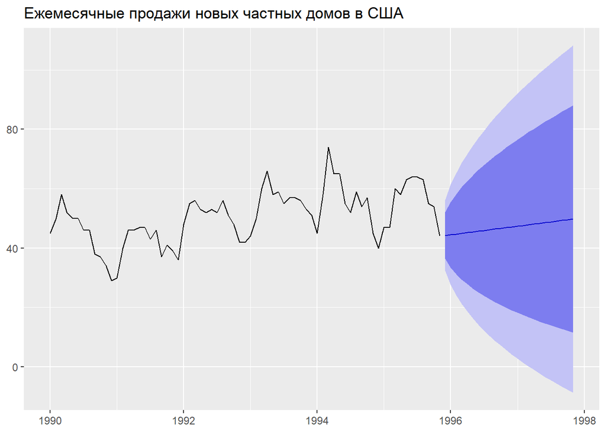

```r
# График прогноза
autoplot(hs90_holt) +
  labs(title = hs90_label,
       fill = 'Доверительный\nинтервал',
       x = NULL, y = NULL)
```

Из сводки по модели видно, что константы сглаживания для тренда и имеют близкие к предельным значения (1 и 0 соответственно). Такая модель практически не сглаживает случайные колебания ряда, и не обновляет тренд при поступлении новых данных.

При необходимости, параметры можно извлечь из модели в виде вектора:

```r
hs90_holt$model$par %>%
  round(5)
```

```
##   alpha    beta       l       b
##  0.9999  0.0001 53.3586  0.2442
```

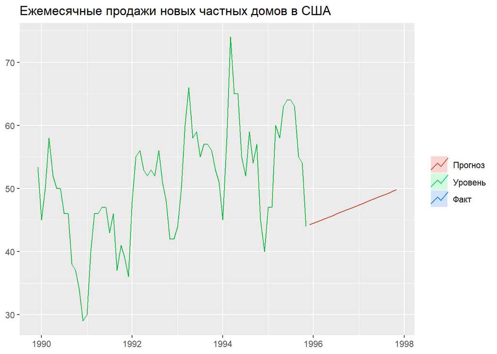

```r
autoplot(hs90, series = 'Факт') +
  autolayer(hs90_holt$model$states[,'l'], series = 'Уровень') +
  autolayer(hs90_holt, PI = FALSE, series = 'Прогноз') +
  labs(title = hs90_label,
     color = NULL,
     x = NULL, y = NULL)
```

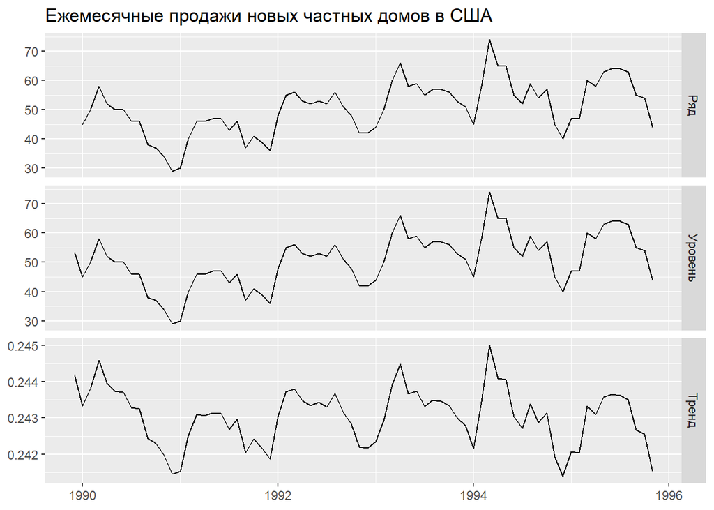

```r
cbind('Ряд' = hs90,
      'Уровень' = hs90_holt$model$states[, 'l'],
      'Тренд' = hs90_holt$model$states[, 'b']) %>%
  autoplot(facets = T) +
  labs(title = hs90_label, y = NULL, x = NULL, color = 'Обозначения')
```

Вспомним, что автоматический подбор параметр основан на сравнении прогноза в историческом периоде и факта и минимизации ошибки подгонки модели. Но модель, которая хорошо объясняет прошлое - не обязательно хорошо предсказывает будущее.

В данном случае очевидно, что компоненты модели плохо адаптируются к данным из-за неудачно подобранных констант. Зададим константы вручную.

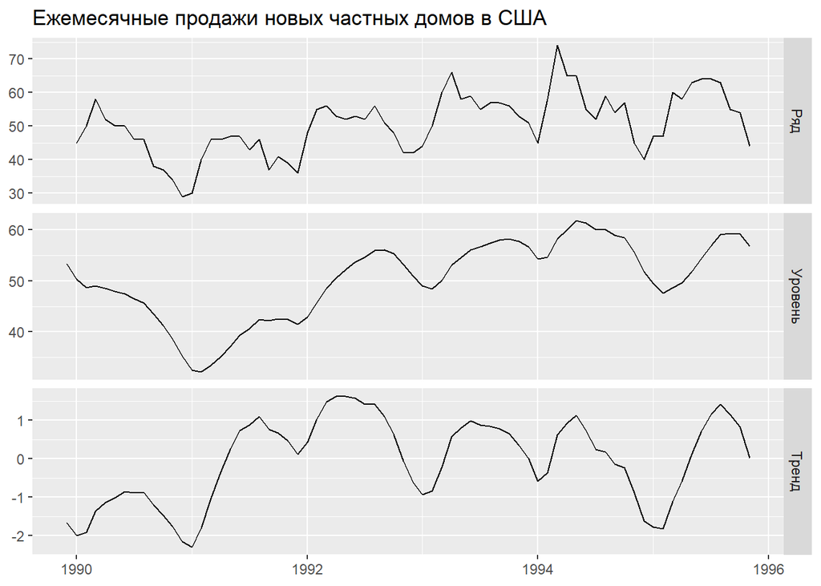

```r
# Прогноз на 24 месяца
hs90_holt_man <- holt(hs90, alpha = 0.2, beta = 0.05, h = 24)
# Начальное значение уровня и тренда подбираются автоматически, константы заданы вручную

# Компоненты ряда
autoplot(cbind('Ряд' = hs90,
               'Уровень' = hs90_holt_man$model$states[, 'l'],
               'Тренд' = hs90_holt_man$model$states[, 'b']),
         facets = T) +
  labs(title = hs90_label, y = NULL, x = NULL, color = 'Обозначения')
```

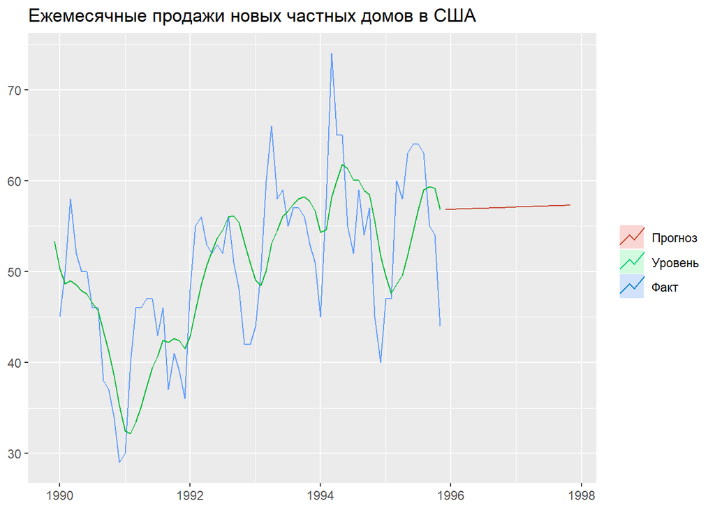

```r
# Прогноз
autoplot(hs90, series = 'Факт') +
  autolayer(hs90_holt_man$model$states[,'l'], series = 'Уровень') +
  autolayer(hs90_holt_man, PI = FALSE, series = 'Прогноз') +
  labs(title = hs90_label,
     color = NULL, x = NULL, y = NULL)
```

# Метод Винтерса

Метод Винтерса позволяет учитывать как скорость изменения ряда, так и сезонность. Существует две модификации метода Винтерса, которые отличаются подходом к учету сезонности: мультипликативная и аддитивная модели.

## Мультипликативная модель Винтерса

В мультипликативной модели Винтерса компоненты выделяются по формулам:

$$L_t = \left( \frac{y_t}{S_{t-m}} \right) \cdot \alpha + (L_{t-1} + b_{t-1})\cdot (1-\alpha)$$

$$b_t = (L_t - L_{t-1}) \cdot \beta + b_{t-1} \cdot (1-\beta)$$

$$S_t = \frac{y_t} {L_t} \cdot \gamma + S_{t-m} \cdot (1-\gamma)$$
Здесь $m$ - длина сезонного цикла.

Для прогнозирования используется уравнение:

$$\hat{y}_{T+h} = (L_{T} + h \cdot b_T) \cdot S_{T-m+h}$$

## Пример

В R мультипликативная модель Винтерса реализуется функцией `forecast::hw()` с параметром `seasonal = 'multiplicative')`.

```r
# Прогноз на 24 месяца
hs90_winters_m <- hw(hs90, h = 24, seasonal = 'multiplicative')
# Константы сглаживания и начальное значение уровня и тренда подбираются автоматически

# Сводка по модели
summary(hs90_winters_m)
```

```
##
## Forecast method: Holt-Winters' multiplicative method
##
## Model Information:
## Holt-Winters' multiplicative method
##
## Call:
##  hw(y = hs90, h = 24, seasonal = "multiplicative")
##
##   Smoothing parameters:
##     alpha = 0.4136
##     beta  = 1e-04
##     gamma = 1e-04
##
##   Initial states:
##     l = 46.1231
##     b = 0.029
##     s = 0.802 0.834 0.946 0.938 1.07 1.02
##            1.07 1.11 1.12 1.2 1.01 0.88
##
##   sigma:  0.0879
##
##  AIC AICc  BIC
##  528  539  566
##
## Error measures:
##                 ME RMSE  MAE   MPE MAPE  MASE  ACF1
## Training set 0.297  3.8 2.99 0.043 6.06 0.459 0.274
##
## Forecasts:
##          Point Forecast Lo 80 Hi 80 Lo 95 Hi 95
## Dec 1995           44.9  39.8  50.0  37.2  52.6
## Jan 1996           49.3  43.3  55.3  40.1  58.4
## Feb 1996           56.4  49.1  63.8  45.2  67.7
## Mar 1996           67.2  57.9  76.6  53.0  81.5
## Apr 1996           63.0  53.8  72.3  48.9  77.2
## May 1996           62.3  52.7  71.9  47.7  76.9
## Jun 1996           60.0  50.3  69.6  45.2  74.7
## Jul 1996           57.4  47.8  67.0  42.7  72.1
## Aug 1996           59.9  49.5  70.3  44.0  75.9
## Sep 1996           52.8  43.3  62.3  38.2  67.3
## Oct 1996           53.2  43.3  63.1  38.1  68.4
## Nov 1996           47.0  37.9  56.0  33.2  60.7
## Dec 1996           45.2  36.3  54.1  31.5  58.9
## Jan 1997           49.6  39.5  59.7  34.2  65.0
## Feb 1997           56.8  45.0  68.7  38.7  74.9
## Mar 1997           67.7  53.2  82.2  45.6  89.8
## Apr 1997           63.5  49.6  77.4  42.2  84.7
## May 1997           62.7  48.7  76.8  41.2  84.2
## Jun 1997           60.4  46.6  74.2  39.2  81.5
## Jul 1997           57.8  44.3  71.3  37.2  78.4
## Aug 1997           60.3  46.0  74.7  38.3  82.3
## Sep 1997           53.1  40.2  66.0  33.4  72.8
## Oct 1997           53.6  40.3  66.8  33.3  73.9
## Nov 1997           47.3  35.4  59.2  29.1  65.5
```

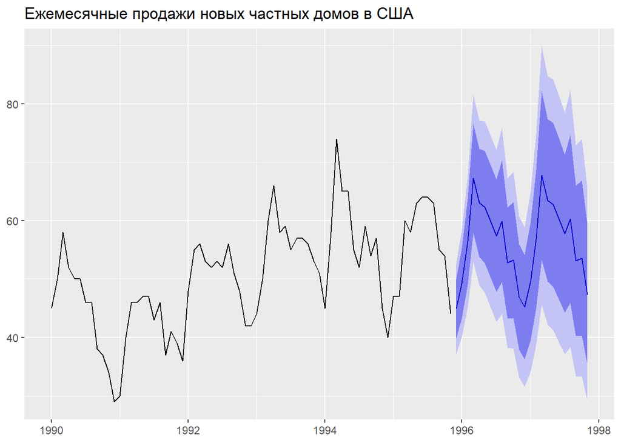

```r
# График прогноза
autoplot(hs90_winters_m) +
  labs(title = hs90_label,
       fill = 'Доверительный\nинтервал',
       x = NULL, y = NULL)
```

Коэффициенты модели:

```r
hs90_winters_m$model$par %>% round(3)
```

```
##  alpha   beta  gamma      l      b     s0     s1     s2     s3     s4
##  0.414  0.000  0.000 46.123  0.029  0.803  0.834  0.946  0.938  1.066
##     s5     s6     s7     s8     s9    s10
##  1.022  1.068  1.110  1.124  1.200  1.008
```

Компоненты ряда:

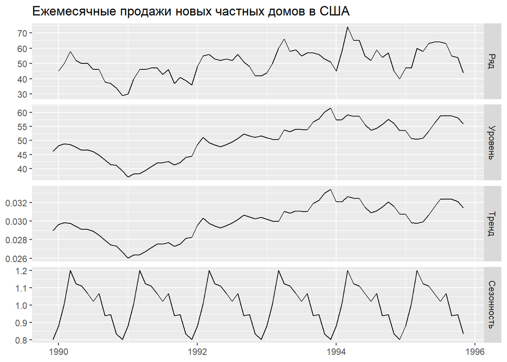

```r
autoplot(cbind('Ряд' = hs90,
               'Уровень' = hs90_winters_m$model$states[, 'l'],
               'Тренд' = hs90_winters_m$model$states[, 'b'],
               'Сезонность' = hs90_winters_m$model$states[, 's1']),
         facets = T) +
  labs(title = hs90_label, y = NULL, x = NULL, color = 'Обозначения')
```

## Аддитивная модель Винтерса

В аддитивной модели Винтерса компоненты выделяются по формулам:

$$L_t = ( y_t - S_{t-m} ) \cdot \alpha + (L_{t-1} + b_{t-1})\cdot (1-\alpha)$$

$$b_t = (L_t - L_{t-1}) \cdot \beta + b_{t-1} \cdot (1-\beta)$$

$$S_t = (y_t - L_t) \cdot \gamma + S_{t-m} \cdot (1-\gamma)$$

Для прогнозирования используется уравнение:

$$\hat{y}_{T+h} = (L_{T} + h \cdot b_T) + S_{T-m+h}$$

## Пример

В R аддитивная модель Винтерса реализуется функцией `forecast::hw()` с параметром `seasonal = 'additive')`.

```r
# Прогноз на 24 месяца
hs90_winters_a <- hw(hs90, h = 24, seasonal = 'additive')
# Константы сглаживания и начальное значение уровня и тренда подбираются автоматически

# Сводка по модели
summary(hs90_winters_a)
```

```
##
## Forecast method: Holt-Winters' additive method
##
## Model Information:
## Holt-Winters' additive method
##
## Call:
##  hw(y = hs90, h = 24, seasonal = "additive")
##
##   Smoothing parameters:
##     alpha = 0.6811
##     beta  = 1e-04
##     gamma = 1e-04
##
##   Initial states:
##     l = 46.9118
##     b = 0.0845
##     s = -9.83 -6.94 -1.13 -1.76 3.73 0.268
##            2.54 5.03 6.05 8.89 0.0506 -6.9
##
##   sigma:  4.24
##
##  AIC AICc  BIC
##  524  535  562
##
## Error measures:
##                    ME RMSE  MAE    MPE MAPE  MASE   ACF1
## Training set -0.00667 3.73 3.06 -0.365 6.13 0.471 0.0753
##
## Forecasts:
##          Point Forecast Lo 80 Hi 80 Lo 95 Hi 95
## Dec 1995           42.8  37.4  48.3  34.5  51.2
## Jan 1996           45.9  39.3  52.4  35.8  55.9
## Feb 1996           52.9  45.4  60.4  41.4  64.4
## Mar 1996           61.8  53.4  70.2  49.0  74.7
## Apr 1996           59.1  49.9  68.3  45.0  73.1
## May 1996           58.1  48.2  68.0  43.0  73.3
## Jun 1996           55.7  45.1  66.3  39.5  71.9
## Jul 1996           53.5  42.3  64.7  36.4  70.7
## Aug 1996           57.1  45.3  68.9  39.0  75.1
## Sep 1996           51.7  39.3  64.0  32.8  70.6
## Oct 1996           52.4  39.5  65.3  32.6  72.2
## Nov 1996           46.7  33.2  60.1  26.1  67.2
## Dec 1996           43.9  29.9  57.8  22.5  65.2
## Jan 1997           46.9  32.4  61.3  24.8  68.9
## Feb 1997           53.9  39.0  68.8  31.1  76.7
## Mar 1997           62.8  47.5  78.2  39.4  86.3
## Apr 1997           60.1  44.3  75.9  35.9  84.2
## May 1997           59.1  42.9  75.4  34.3  84.0
## Jun 1997           56.7  40.1  73.4  31.3  82.2
## Jul 1997           54.6  37.5  71.6  28.5  80.6
## Aug 1997           58.1  40.6  75.5  31.4  84.8
## Sep 1997           52.7  34.8  70.5  25.4  80.0
## Oct 1997           53.4  35.2  71.6  25.5  81.3
## Nov 1997           47.7  29.1  66.3  19.2  76.1
```

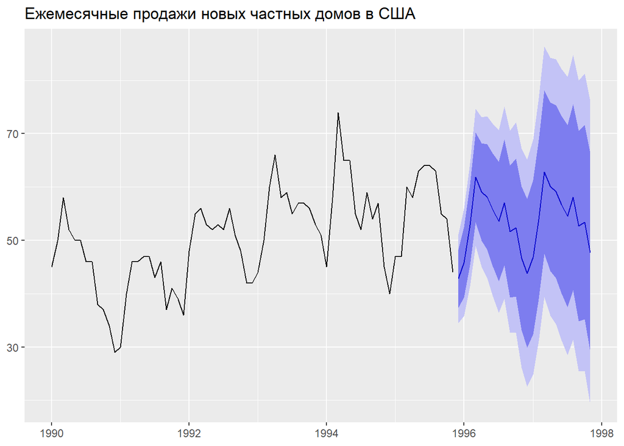

```r
# График прогноза
autoplot(hs90_winters_a) +
  labs(title = hs90_label,
       fill = 'Доверительный\nинтервал',
       x = NULL, y = NULL)
```

Коэффициенты модели:

```r
hs90_winters_a$model$par %>% round(3)
```

```
##  alpha   beta  gamma      l      b     s0     s1     s2     s3     s4
##  0.681  0.000  0.000 46.912  0.084 -9.829 -6.938 -1.125 -1.764  3.730
##     s5     s6     s7     s8     s9    s10
##  0.268  2.539  5.029  6.051  8.891  0.051
```

Компоненты ряда:

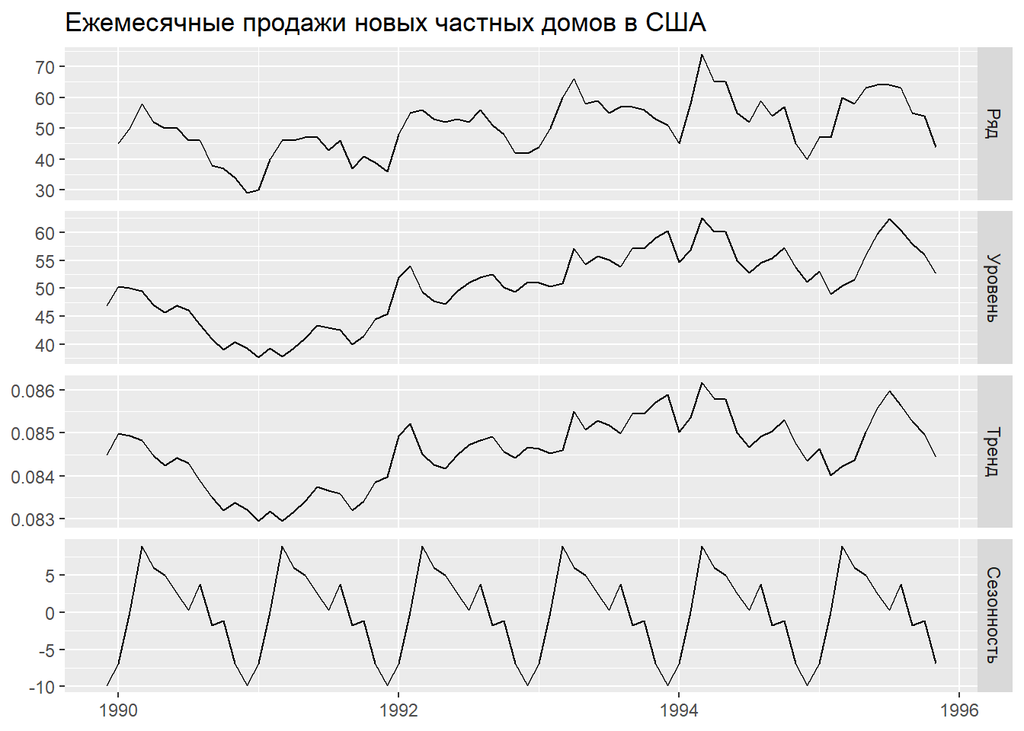

```r
autoplot(cbind('Ряд' = hs90,
               'Уровень' = hs90_winters_a$model$states[, 'l'],
               'Тренд' = hs90_winters_a$model$states[, 'b'],
               'Сезонность' = hs90_winters_a$model$states[, 's1']),
         facets = T) +
  labs(title = hs90_label, y = NULL, x = NULL, color = 'Обозначения')
```

## Сравнение аддитивной и мультипликативной моделей Винтерса

### Визуальное сравнение

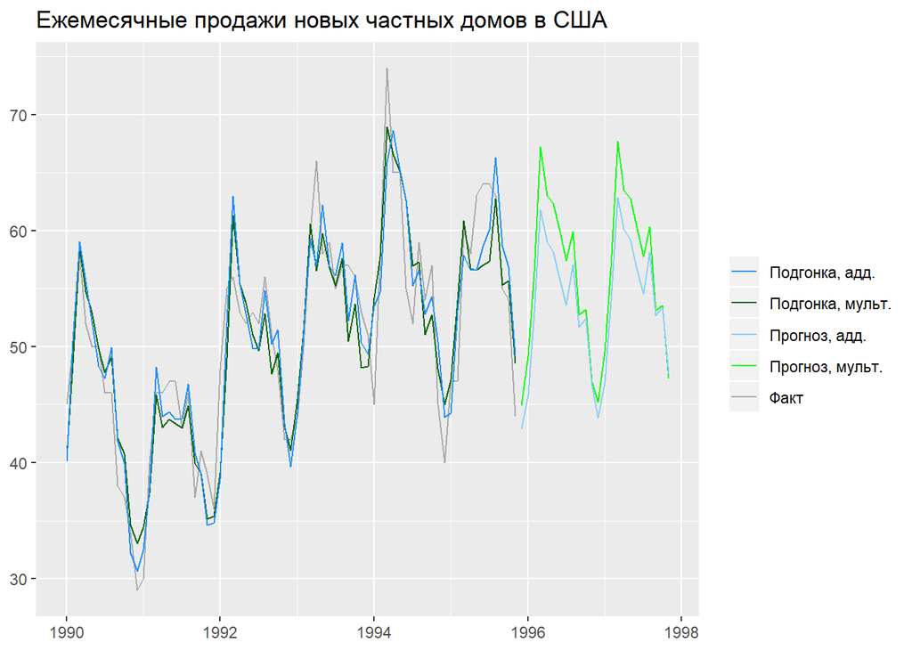

```r
autoplot(hs90, series = 'Факт') +
  autolayer(fitted(hs90_winters_m), series = 'Подгонка, мульт.') +
  autolayer(fitted(hs90_winters_a), series = 'Подгонка, адд.') +
  autolayer(hs90_winters_m$mean, series = 'Прогноз, мульт.') +
  autolayer(hs90_winters_a$mean, series = 'Прогноз, адд.') +
  labs(title = hs90_label, color = NULL,
     x = NULL, y = NULL) +

  scale_color_manual(values = c('dodgerblue', 'darkgreen',
                                'lightskyblue', 'green', 'darkgray'))
```

### Сравнение параметров

```r
# Мультипликативная модель
hs90_winters_m$model$par[1:3] %>% round(4)
```

```
##  alpha   beta  gamma
## 0.4136 0.0001 0.0001
```

```r
# Аддитивная модель
hs90_winters_a$model$par[1:3] %>% round(4)
```

```
##  alpha   beta  gamma
## 0.6811 0.0001 0.0001
```

### Сравнение ошибок на обучающем периоде

```r
acc <- rbind(accuracy(hs90_winters_m),
             accuracy(hs90_winters_a))

rownames(acc) <- c('Мульт. модель', 'Адд.модель')
acc
```

```
##                     ME RMSE  MAE    MPE MAPE  MASE   ACF1
## Мульт. модель  0.29693 3.80 2.99  0.043 6.06 0.459 0.2737
## Адд.модель    -0.00667 3.73 3.06 -0.365 6.13 0.471 0.0753
```

```r
rbind(accuracy(hs90_winters_m),
      accuracy(hs90_winters_a)) %>%
  as_tibble() %>%
  round(4) %>%
  mutate(`Метод` = c('Мультипликативная модель',
                     'Аддитивная модель')) %>%
  select(`Метод`, MASE, MAPE, MPE) %>%
  arrange(MASE)
```

```
## # A tibble: 2 x 4
##   Метод                     MASE  MAPE    MPE
##   <chr>                    <dbl> <dbl>  <dbl>
## 1 Мультипликативная модель 0.459  6.06  0.043
## 2 Аддитивная модель        0.471  6.13 -0.365
```

Попробуем сравнить их на тестовом периоде:

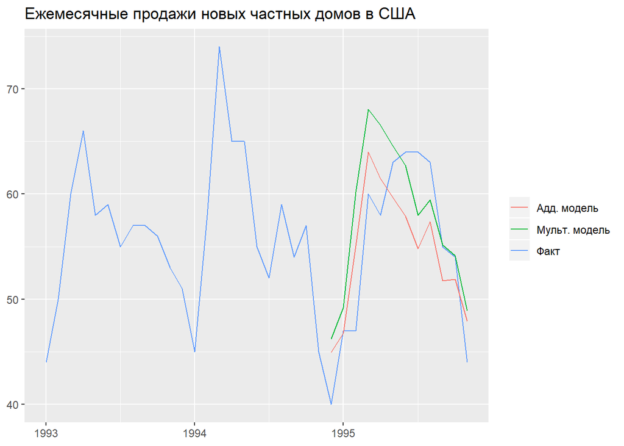

```r
# Подготовка данных обучающего периода:
hs90_train <-
  window(hs90, end = c(1994, 11))

# Построение моделей:
hs90_wa_expost <- hw(hs90_train, h = 12, seasonal = 'additive')
hs90_wm_expost <- hw(hs90_train, h = 12, seasonal = 'multiplicative')

# Визуализация прогнозов:
hs90 %>% window(start = 1993) %>%
  autoplot(series = 'Факт') +
    autolayer(hs90_wa_expost$mean,  series = 'Адд. модель') +
    autolayer(hs90_wm_expost$mean,  series = 'Мульт. модель') +
    labs(title = hs90_label,
       color = NULL,
       x = NULL, y = NULL)
```

```r
# Сравнение ошибок в тестовом периоде:
rbind(
  accuracy(hs90_wa_expost, hs90)['Test set',],
  accuracy(hs90_wm_expost, hs90)['Test set',]) %>%
  as_tibble() %>%
  round(4) %>%
  mutate(`Метод` = c('Аддитивная модель',
                     'Мультипликативная модель')) %>%
  select(`Метод`, MASE, MAPE, MPE) %>%
  arrange(MASE)
```

```
## # A tibble: 2 x 4
##   Метод                     MASE  MAPE    MPE
##   <chr>                    <dbl> <dbl>  <dbl>
## 1 Аддитивная модель        0.692  8.29 -0.222
## 2 Мультипликативная модель 0.712  8.97 -6.13
```